# Unidad 2 – Operaciones Morfológicas

## 1 Objetivos de aprendizaje

- Comprender los fundamentos de la morfología matemática
- Aplicar binarización (threshold simple y Otsu)
- Implementar erosión y dilatación
- Utilizar operaciones compuestas (apertura y cierre)
- Reconocer aplicaciones prácticas de morfología

## 2 ¿Qué es la morfología matemática?

- Conjunto de técnicas para analizar la **forma** de objetos en imágenes
- Se basa en la **teoría de conjuntos**
- Principalmente aplicada a **imágenes binarias** (blanco/negro)
- Usa un **elemento estructurante** (kernel) para explorar la imagen

**Aplicaciones:**

- Eliminación de ruido
- Extracción de componentes
- Detección de formas
- Preprocesamiento para segmentación

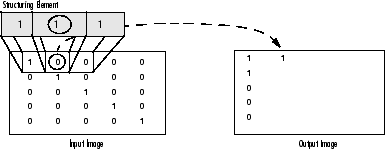

Morfología

## 3 Paso previo: Binarización

Antes de aplicar morfología, necesitamos una **imagen binaria**:

**Threshold simple:**
$$g(x,y) = \begin{cases}
255 & \text{si } f(x,y) > T \\
0 & \text{si } f(x,y) \leq T
\end{cases}$$

**Método de Otsu (automático):**

- Calcula el umbral óptimo que minimiza la varianza intra-clase
- No requiere especificar el umbral manualmente

## 4 Ejemplo: Binarización

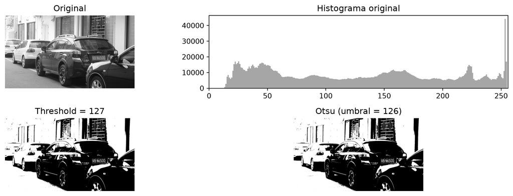

```python
import cv2
import matplotlib.pyplot as plt
import numpy as np

# Cargar imagen
img = cv2.imread("imagenes/DPP0357.TIF", cv2.IMREAD_GRAYSCALE)


# Threshold simple (manual)
_, binary_simple = cv2.threshold(img, 127, 255, cv2.THRESH_BINARY)

# Threshold de Otsu (automático)
umbral_otsu, binary_otsu = cv2.threshold(img, 0, 255,
                                          cv2.THRESH_BINARY + cv2.THRESH_OTSU)


# Visualización
plt.figure(figsize=(12,4))
plt.subplot(2,2,1)
plt.imshow(img, cmap='gray')
plt.title('Original')
plt.axis('off')

plt.subplot(2,2,2)
plt.hist(img.ravel(), bins=256, color='gray', alpha=0.7)
plt.title('Histograma original')
plt.xlim([0,256])

plt.subplot(2,2,3)
plt.imshow(binary_simple, cmap='gray')
plt.title('Threshold = 127')
plt.axis('off')

plt.subplot(2,2,4)
plt.imshow(binary_otsu, cmap='gray')
plt.title(f'Otsu (umbral = {umbral_otsu:.0f})')
plt.axis('off')

plt.tight_layout()
plt.show()
```

## 5 Elemento estructurante

- Es una **matriz pequeña** (kernel) que define el vecindario
- Determina qué píxeles son afectados por la operación
- Formas comunes: rectangular, elíptica, cruz

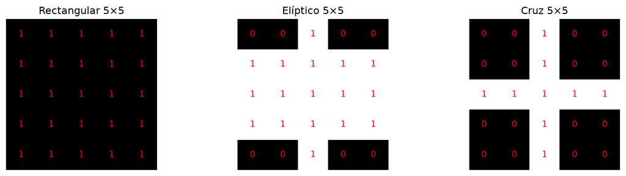

```python
# Elementos estructurantes en OpenCV
kernel_rect = cv2.getStructuringElement(cv2.MORPH_RECT, (5,5))
kernel_ellipse = cv2.getStructuringElement(cv2.MORPH_ELLIPSE, (5,5))
kernel_cross = cv2.getStructuringElement(cv2.MORPH_CROSS, (5,5))

# Visualización
fig, axes = plt.subplots(1, 3, figsize=(12,3))
titles = ['Rectangular 5×5', 'Elíptico 5×5', 'Cruz 5×5']
kernels = [kernel_rect, kernel_ellipse, kernel_cross]

for ax, kernel, title in zip(axes, kernels, titles):
    ax.imshow(kernel, cmap='gray', interpolation='nearest')
    ax.set_title(title)
    ax.axis('off')
    # Mostrar valores
    for i in range(kernel.shape[0]):
        for j in range(kernel.shape[1]):
            ax.text(j, i, str(kernel[i,j]),
                   ha='center', va='center', color='red', fontsize=10)

plt.tight_layout()
plt.show()
```

## 6 Erosión

- **Reduce** el tamaño de los objetos blancos
- Elimina píxeles en los **bordes** de los objetos
- Útil para **eliminar ruido pequeño**

**Definición matemática:**
$$(A \ominus B)(x,y) = \min_{(i,j) \in B} A(x+i, y+j)$$

**Efectos:**  
- Objetos pequeños desaparecen  
- Los huecos se agrandan  
- Los objetos se adelgazan

## 7 Ejemplo: Erosión

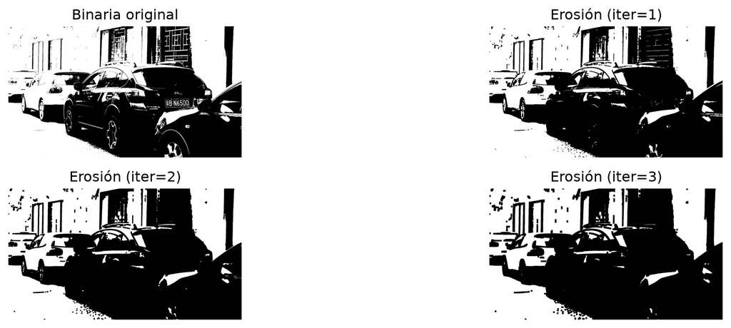

```python
# Binarizar primero
_, binary = cv2.threshold(img, 0, 255, cv2.THRESH_BINARY + cv2.THRESH_OTSU)

# Crear kernel
kernel = cv2.getStructuringElement(cv2.MORPH_RECT, (5,5))

# Aplicar erosión con diferente número de iteraciones
erosion_1 = cv2.erode(binary, kernel, iterations=1)
erosion_2 = cv2.erode(binary, kernel, iterations=2)
erosion_3 = cv2.erode(binary, kernel, iterations=3)

# Visualización
plt.figure(figsize=(14,4))
plt.subplot(2,2,1)
plt.imshow(binary, cmap='gray')
plt.title('Binaria original')
plt.axis('off')

plt.subplot(2,2,2)
plt.imshow(erosion_1, cmap='gray')
plt.title('Erosión (iter=1)')
plt.axis('off')

plt.subplot(2,2,3)
plt.imshow(erosion_2, cmap='gray')
plt.title('Erosión (iter=2)')
plt.axis('off')

plt.subplot(2,2,4)
plt.imshow(erosion_3, cmap='gray')
plt.title('Erosión (iter=3)')
plt.axis('off')

plt.tight_layout()
plt.show()
```

## 8 Dilatación

- **Expande** el tamaño de los objetos blancos
- Añade píxeles en los **bordes** de los objetos
- Útil para **conectar regiones cercanas**

**Definición matemática:**
$$(A \oplus B)(x,y) = \max_{(i,j) \in B} A(x+i, y+j)$$

**Efectos:**  
- Los objetos crecen  
- Los huecos se rellenan  
- Los objetos cercanos se conectan

## 9 Ejemplo: Dilatación

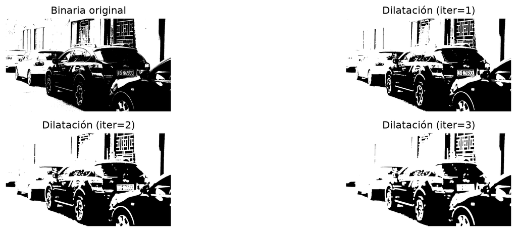

```python
# Aplicar dilatación con diferente número de iteraciones
dilatacion_1 = cv2.dilate(binary, kernel, iterations=1)
dilatacion_2 = cv2.dilate(binary, kernel, iterations=2)
dilatacion_3 = cv2.dilate(binary, kernel, iterations=3)

# Visualización
plt.figure(figsize=(14,4))
plt.subplot(2,2,1)
plt.imshow(binary, cmap='gray')
plt.title('Binaria original')
plt.axis('off')

plt.subplot(2,2,2)
plt.imshow(dilatacion_1, cmap='gray')
plt.title('Dilatación (iter=1)')
plt.axis('off')

plt.subplot(2,2,3)
plt.imshow(dilatacion_2, cmap='gray')
plt.title('Dilatación (iter=2)')
plt.axis('off')

plt.subplot(2,2,4)
plt.imshow(dilatacion_3, cmap='gray')
plt.title('Dilatación (iter=3)')
plt.axis('off')

plt.tight_layout()
plt.show()
```

## 10 Comparación: Erosión vs Dilatación

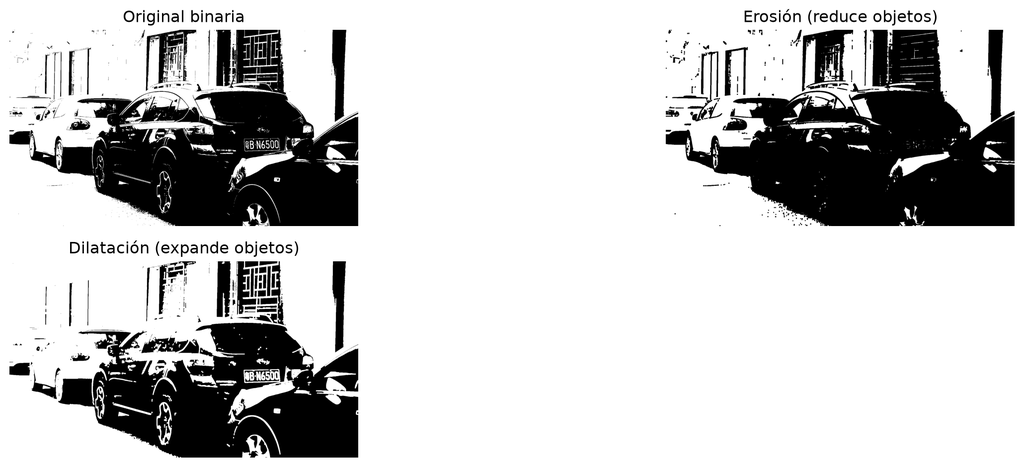

```python
# Comparación lado a lado con una sola iteración
plt.figure(figsize=(15,5))

plt.subplot(2,2,1)
plt.imshow(binary, cmap='gray')
plt.title('Original binaria')
plt.axis('off')

plt.subplot(2,2,2)
plt.imshow(erosion_1, cmap='gray')
plt.title('Erosión (reduce objetos)')
plt.axis('off')

plt.subplot(2,2,3)
plt.imshow(dilatacion_1, cmap='gray')
plt.title('Dilatación (expande objetos)')
plt.axis('off')

plt.tight_layout()
plt.show()
```

## 11 Apertura (Opening)

**Apertura = Erosión + Dilatación**

$$A \circ B = (A \ominus B) \oplus B$$

**Efectos:**

- Elimina **ruido externo** pequeño
- Suaviza **contornos externos**
- Separa objetos conectados débilmente
- Preserva el tamaño aproximado de objetos grandes

**Uso típico:**

- Limpiar ruido tipo “sal” (píxeles blancos aislados)

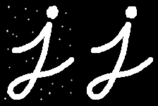

Apertura

## 12 Ejemplo: Apertura

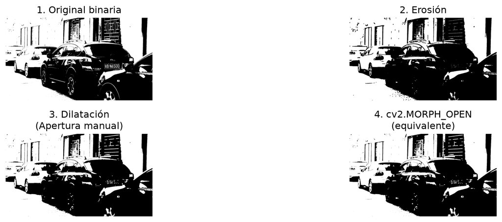

```python
# Apertura con cv2.morphologyEx
apertura = cv2.morphologyEx(binary, cv2.MORPH_OPEN, kernel)

# Comparar paso a paso
erosion_temp = cv2.erode(binary, kernel, iterations=1)
apertura_manual = cv2.dilate(erosion_temp, kernel, iterations=1)

# Visualización
plt.figure(figsize=(15,4))
plt.subplot(2,2,1)
plt.imshow(binary, cmap='gray')
plt.title('1. Original binaria')
plt.axis('off')

plt.subplot(2,2,2)
plt.imshow(erosion_temp, cmap='gray')
plt.title('2. Erosión')
plt.axis('off')

plt.subplot(2,2,3)
plt.imshow(apertura_manual, cmap='gray')
plt.title('3. Dilatación\n(Apertura manual)')
plt.axis('off')

plt.subplot(2,2,4)
plt.imshow(apertura, cmap='gray')
plt.title('4. cv2.MORPH_OPEN\n(equivalente)')
plt.axis('off')

plt.tight_layout()
plt.show()
```

## 13 Cierre (Closing)

**Cierre = Dilatación + Erosión**

$$A \bullet B = (A \oplus B) \ominus B$$

**Efectos:**

- Rellena **huecos internos** pequeños
- Suaviza **contornos internos**
- Conecta regiones cercanas
- Preserva el tamaño aproximado de objetos

**Uso típico:**

- Limpiar ruido tipo “pimienta” (píxeles negros en objetos)

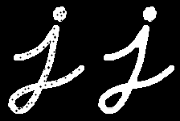

Cierre

## 14 Ejemplo: Cierre

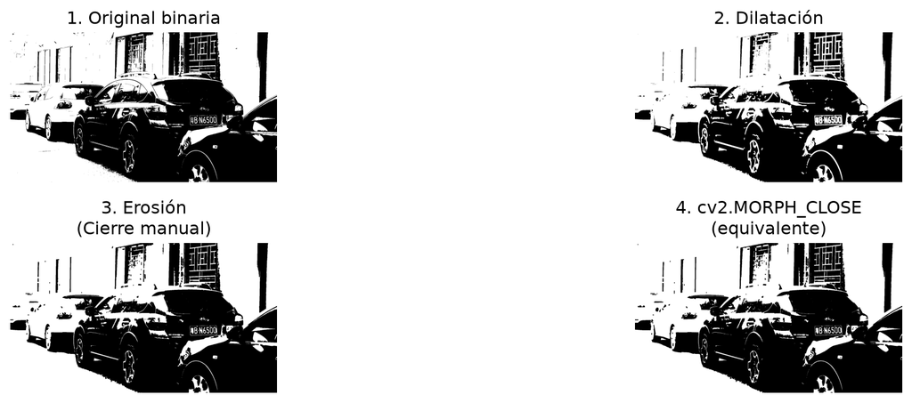

```python
# Cierre con cv2.morphologyEx
cierre = cv2.morphologyEx(binary, cv2.MORPH_CLOSE, kernel)

# Comparar paso a paso
dilatacion_temp = cv2.dilate(binary, kernel, iterations=1)
cierre_manual = cv2.erode(dilatacion_temp, kernel, iterations=1)

# Visualización
plt.figure(figsize=(15,4))
plt.subplot(2,2,1)
plt.imshow(binary, cmap='gray')
plt.title('1. Original binaria')
plt.axis('off')

plt.subplot(2,2,2)
plt.imshow(dilatacion_temp, cmap='gray')
plt.title('2. Dilatación')
plt.axis('off')

plt.subplot(2,2,3)
plt.imshow(cierre_manual, cmap='gray')
plt.title('3. Erosión\n(Cierre manual)')
plt.axis('off')

plt.subplot(2,2,4)
plt.imshow(cierre, cmap='gray')
plt.title('4. cv2.MORPH_CLOSE\n(equivalente)')
plt.axis('off')

plt.tight_layout()
plt.show()
```

## 15 Comparación: Apertura vs Cierre

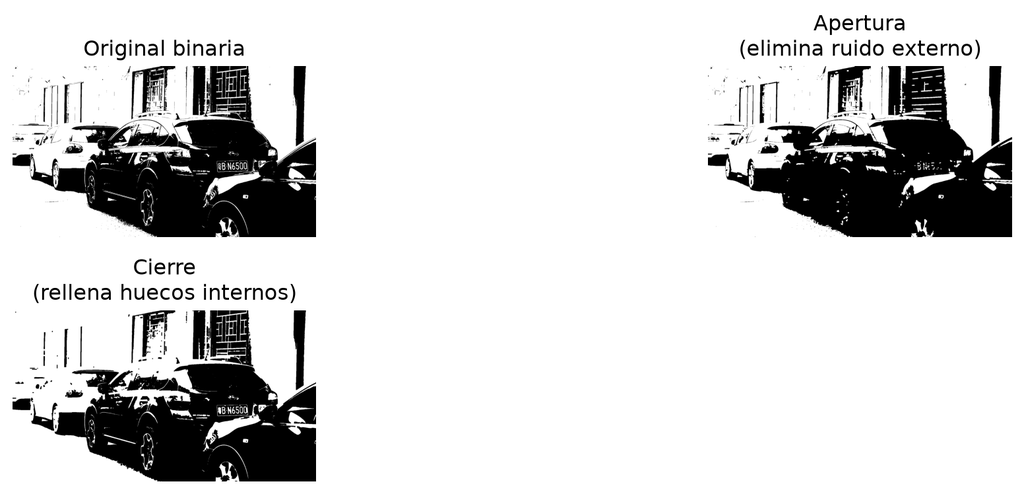

```python
plt.figure(figsize=(12,4))

plt.subplot(2,2,1)
plt.imshow(binary, cmap='gray')
plt.title('Original binaria')
plt.axis('off')

plt.subplot(2,2,2)
plt.imshow(apertura, cmap='gray')
plt.title('Apertura\n(elimina ruido externo)')
plt.axis('off')

plt.subplot(2,2,3)
plt.imshow(cierre, cmap='gray')
plt.title('Cierre\n(rellena huecos internos)')
plt.axis('off')

plt.tight_layout()
plt.show()
```

## 16 Ejemplo práctico: Limpieza de ruido

```python
# Añadir ruido sal y pimienta a la imagen binaria
def agregar_ruido_sp(imagen, prob_sal=0.01, prob_pimienta=0.01):
    """Agrega ruido sal y pimienta a una imagen binaria"""
    ruidosa = imagen.copy()

    # Sal (píxeles blancos)
    num_sal = int(prob_sal * imagen.size)
    coords_sal = [np.random.randint(0, i, num_sal)
                  for i in imagen.shape]
    ruidosa[coords_sal[0], coords_sal[1]] = 255

    # Pimienta (píxeles negros)
    num_pimienta = int(prob_pimienta * imagen.size)
    coords_pimienta = [np.random.randint(0, i, num_pimienta)
                       for i in imagen.shape]
    ruidosa[coords_pimienta[0], coords_pimienta[1]] = 0

    return ruidosa

# Crear imagen con ruido
binary_ruidosa = agregar_ruido_sp(binary, prob_sal=0.02, prob_pimienta=0.02)

# Limpiar con apertura (elimina sal)
limpia_apertura = cv2.morphologyEx(binary_ruidosa, cv2.MORPH_OPEN, kernel)

# Limpiar con cierre (elimina pimienta)
limpia_cierre = cv2.morphologyEx(limpia_apertura, cv2.MORPH_CLOSE, kernel)
```

## 17 Resultado de limpieza

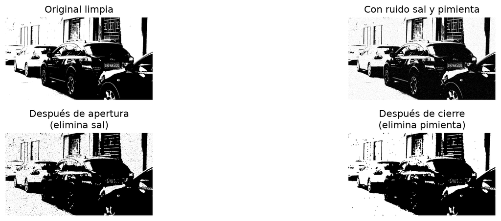

```python
plt.figure(figsize=(15,4))

plt.subplot(2,2,1)
plt.imshow(binary, cmap='gray')
plt.title('Original limpia')
plt.axis('off')

plt.subplot(2,2,2)
plt.imshow(binary_ruidosa, cmap='gray')
plt.title('Con ruido sal y pimienta')
plt.axis('off')

plt.subplot(2,2,3)
plt.imshow(limpia_apertura, cmap='gray')
plt.title('Después de apertura\n(elimina sal)')
plt.axis('off')

plt.subplot(2,2,4)
plt.imshow(limpia_cierre, cmap='gray')
plt.title('Después de cierre\n(elimina pimienta)')
plt.axis('off')

plt.tight_layout()
plt.show()
```

## 18 Otras operaciones morfológicas

**Gradiente morfológico:**
$$\text{Gradiente} = \text{Dilatación} - \text{Erosión}$$
Resalta los **bordes** de los objetos

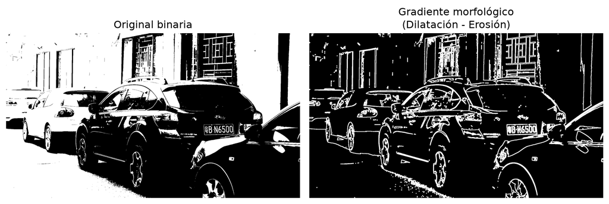

```python
gradiente = cv2.morphologyEx(binary, cv2.MORPH_GRADIENT, kernel)

plt.figure(figsize=(10,4))
plt.subplot(1,2,1)
plt.imshow(binary, cmap='gray')
plt.title('Original binaria')
plt.axis('off')

plt.subplot(1,2,2)
plt.imshow(gradiente, cmap='gray')
plt.title('Gradiente morfológico\n(Dilatación - Erosión)')
plt.axis('off')

plt.tight_layout()
plt.show()
```

## 19 Top Hat y Black Hat

**Top Hat:**
$$\text{Top Hat} = \text{Original} - \text{Apertura}$$
Extrae objetos **pequeños brillantes**

**Black Hat:**
$$\text{Black Hat} = \text{Cierre} - \text{Original}$$
Extrae objetos **pequeños oscuros**

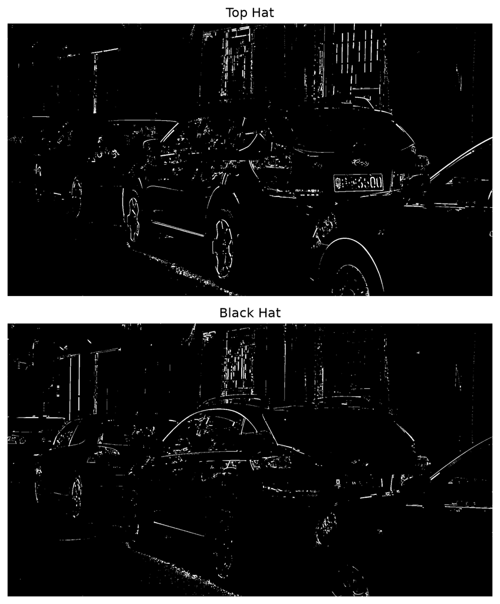

```python
tophat = cv2.morphologyEx(binary,
    cv2.MORPH_TOPHAT, kernel)
blackhat = cv2.morphologyEx(binary,
    cv2.MORPH_BLACKHAT, kernel)

plt.figure(figsize=(8,8))
plt.subplot(2,1,1)
plt.imshow(tophat, cmap='gray')
plt.title('Top Hat')
plt.axis('off')

plt.subplot(2,1,2)
plt.imshow(blackhat, cmap='gray')
plt.title('Black Hat')
plt.axis('off')

plt.tight_layout()
plt.show()
```

## 20 Resumen de operaciones

| Operación | Fórmula | Efecto | Uso típico |
| --- | --- | --- | --- |
| **Erosión** | $A \ominus B$ | Reduce objetos | Eliminar ruido pequeño |
| **Dilatación** | $A \oplus B$ | Expande objetos | Conectar regiones |
| **Apertura** | $(A \ominus B) \oplus B$ | Elimina ruido externo | Limpiar “sal” |
| **Cierre** | $(A \oplus B) \ominus B$ | Rellena huecos | Limpiar “pimienta” |
| **Gradiente** | Dilatación - Erosión | Detecta bordes | Segmentación |
| **Top Hat** | Original - Apertura | Objetos brillantes | Detección de picos |
| **Black Hat** | Cierre - Original | Objetos oscuros | Detección de valles |

## 21 Ejemplo integrador

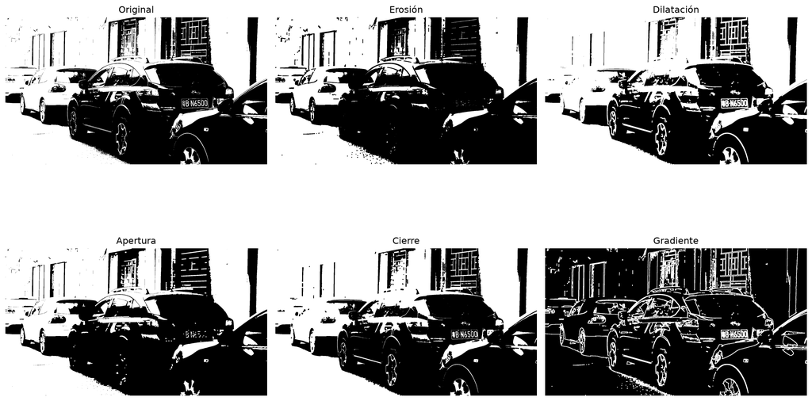

```python
# Crear un ejemplo visual completo
operaciones = {
    'Original': binary,
    'Erosión': cv2.erode(binary, kernel, iterations=1),
    'Dilatación': cv2.dilate(binary, kernel, iterations=1),
    'Apertura': cv2.morphologyEx(binary, cv2.MORPH_OPEN, kernel),
    'Cierre': cv2.morphologyEx(binary, cv2.MORPH_CLOSE, kernel),
    'Gradiente': cv2.morphologyEx(binary, cv2.MORPH_GRADIENT, kernel)
}

fig, axes = plt.subplots(2, 3, figsize=(15, 10))
axes = axes.ravel()

for i, (nombre, imagen) in enumerate(operaciones.items()):
    axes[i].imshow(imagen, cmap='gray')
    axes[i].set_title(nombre, fontsize=12)
    axes[i].axis('off')

plt.tight_layout()
plt.show()
```

## 22 Tamaño del kernel importa

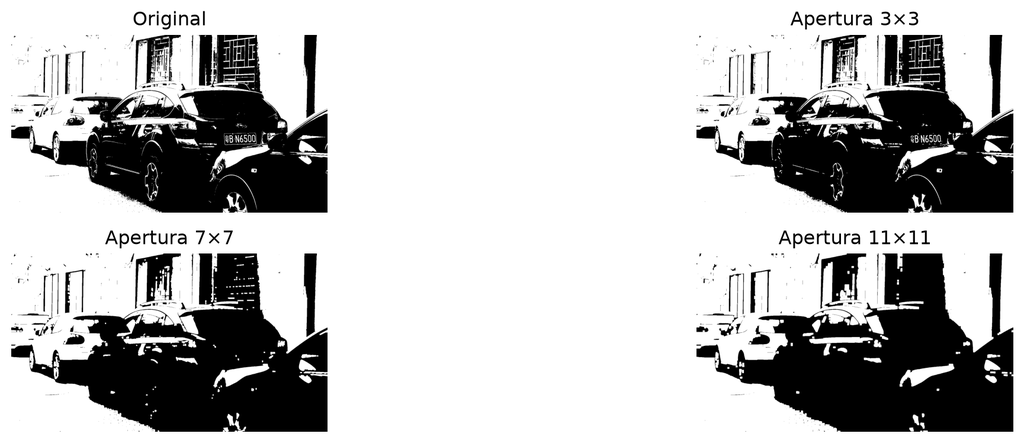

```python
# Comparar diferentes tamaños de kernel
kernel_3 = cv2.getStructuringElement(cv2.MORPH_RECT, (3,3))
kernel_7 = cv2.getStructuringElement(cv2.MORPH_RECT, (7,7))
kernel_11 = cv2.getStructuringElement(cv2.MORPH_RECT, (11,11))

apertura_3 = cv2.morphologyEx(binary, cv2.MORPH_OPEN, kernel_3)
apertura_7 = cv2.morphologyEx(binary, cv2.MORPH_OPEN, kernel_7)
apertura_11 = cv2.morphologyEx(binary, cv2.MORPH_OPEN, kernel_11)

plt.figure(figsize=(15,4))
plt.subplot(2,2,1)
plt.imshow(binary, cmap='gray')
plt.title('Original')
plt.axis('off')

plt.subplot(2,2,2)
plt.imshow(apertura_3, cmap='gray')
plt.title('Apertura 3×3')
plt.axis('off')

plt.subplot(2,2,3)
plt.imshow(apertura_7, cmap='gray')
plt.title('Apertura 7×7')
plt.axis('off')

plt.subplot(2,2,4)
plt.imshow(apertura_11, cmap='gray')
plt.title('Apertura 11×11')
plt.axis('off')

plt.tight_layout()
plt.show()
```

## 23 Aplicaciones prácticas

**Preprocesamiento:**  
- Eliminación de ruido  
- Separación de objetos  
- Relleno de huecos

**Detección de características:**  
- Extracción de esqueletos  
- Detección de esquinas  
- Identificación de formas

**Segmentación:**  
- Separación de regiones  
- Detección de bordes  
- Análisis de componentes conectadas

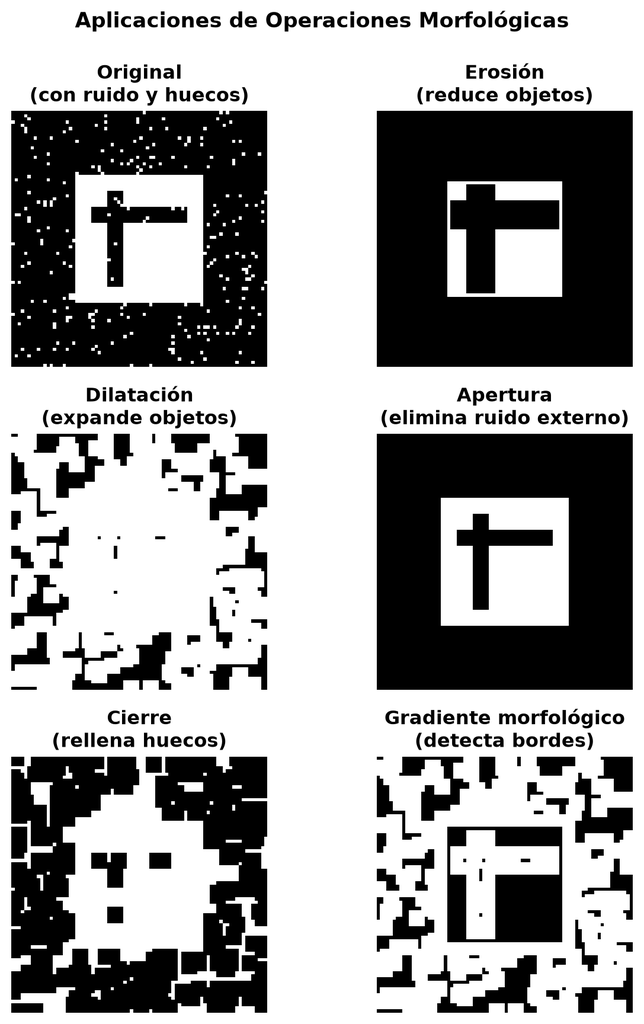

## 24 Conclusiones

- La **binarización** es el paso previo esencial (Otsu es automático y robusto)
- El **elemento estructurante** define el alcance de las operaciones
- **Erosión** reduce objetos, **dilatación** los expande
- **Apertura** elimina ruido externo, **cierre** rellena huecos
- Combinar operaciones morfológicas es clave para limpiar imágenes
- El **tamaño del kernel** afecta significativamente el resultado

## 25 Aprende más

- Gonzalez, R. C., & Woods, R. E. (2018). *Digital Image Processing*. Capítulo 9.
- OpenCV Documentation: [Morphological Transformations](https://docs.opencv.org/4.x/d9/d61/tutorial_py_morphological_ops.html)
- Serra, J. (1982). *Image Analysis and Mathematical Morphology*.